# rapport

## C. Prise en main des données

### 1. L’équipe la plus chère

```r
print(equipe_chere %>% select(name, club_position_cat, overall_rating, value_num))
```

```
## # A tibble: 11 × 4
##    name                               club_position_cat overall_rating value_num
##    <chr>                              <chr>                      <dbl>     <dbl>
##  1 Jude Victor William Bellingham -   MID                           90 174500000
##  2 Vini Jr. -                         FWD                           90 171500000
##  3 Kylian Mbappé Lottin -             FWD                           90 160000000
##  4 Florian Richard Wirtz -            MID                           89 143500000
##  5 Lamine Yamal -                     MID                           86 140500000
##  6 Jamal Musiala -                    MID                           88 133500000
##  7 William Alain André Gabriel Salib… DEF                           87  92000000
##  8 Alessandro Bastoni -               DEF                           87  88500000
##  9 Jules Olivier Koundé -             DEF                           86  83000000
## 10 Achraf Hakimi Mouh -               DEF                           86  78500000
## 11 Gianluigi Donnarumma -             GK                            87  76000000
```

### 2. L’équipe la plus forte

```r
print(equipe_forte %>% select(name, club_position_cat, overall_rating, value_num))
```

```
## # A tibble: 11 × 4
##    name                               club_position_cat overall_rating value_num
##    <chr>                              <chr>                      <dbl>     <dbl>
##  1 Mohamed Salah Hamed Ghaly -        MID                           91 104000000
##  2 Jude Victor William Bellingham -   MID                           90 174500000
##  3 Vini Jr. -                         FWD                           90 171500000
##  4 Kylian Mbappé Lottin -             FWD                           90 160000000
##  5 Virgil van Dijk -                  DEF                           90  77500000
##  6 Florian Richard Wirtz -            MID                           89 143500000
##  7 Alisson -                          GK                            89  54500000
##  8 Kevin De Bruyne -                  MID                           89  63500000
##  9 Antonio Rüdiger -                  DEF                           88  62500000
## 10 William Alain André Gabriel Salib… DEF                           87  92000000
## 11 Alessandro Bastoni -               DEF                           87  88500000
```

### 3. Comparaison

```r
cat("Joueurs en commun:", length(joueurs_communs), "sur 11\n")
```

```
## Joueurs en commun: 6 sur 11
```

```r
if(length(joueurs_communs) > 0) {
  cat("Noms:", paste(joueurs_communs, collapse = ", "), "\n")
} else {
  cat("Aucun joueur en commun\n")
}
```

```
## Noms: Jude Victor William Bellingham -, Vini Jr. -, Kylian Mbappé Lottin -, Florian Richard Wirtz -, William Alain André Gabriel Saliba -, Alessandro Bastoni -
```

Nous observons que les deux équipes ne sont pas formées totalement par les même joueurs. Avec seulement 6 joueurs en commun sur 11, cela signifie que 5 joueurs diffèrent entre l’équipe la plus chère et l’équipe la plus forte (soit environ 45% de l’effectif). **Conclusion par rapport à l’analyse de corrélation** : Ce résultat confirme parfaitement notre observation dans l’analyse de la matrice de corrélation, où nous avions constaté une corrélation modérée de 0,63 entre `overall_rating` et `value_num`. Cette corrélation, bien que significative, n’était pas parfaite, et nous avions conclu que d’autres facteurs influençaient la valeur marchande au-delà de la seule performance actuelle. Ces résultat confirme bien notre précedente conclusion.

### 4. Une équipe par ligue ou par pays

```r
cat("\n=== ÉQUIPE PREMIER LEAGUE ===\n")
```

```
##
## === ÉQUIPE PREMIER LEAGUE ===
```

```r
print(equipe_premier_league %>% select(name, club_position_cat, overall_rating, club_name))
```

```
## # A tibble: 11 × 4
##    name                               club_position_cat overall_rating club_name
##    <chr>                              <chr>                      <dbl> <chr>
##  1 Mohamed Salah Hamed Ghaly -        MID                           91 Liverpool
##  2 Virgil van Dijk -                  DEF                           90 Liverpool
##  3 Alisson -                          GK                            89 Liverpool
##  4 Kevin De Bruyne -                  MID                           89 Manchest…
##  5 Bukayo Saka -                      FWD                           88 Arsenal
##  6 Cole Jermaine Palmer -             MID                           87 Chelsea
##  7 William Alain André Gabriel Salib… DEF                           87 Arsenal
##  8 Declan Rice -                      MID                           87 Arsenal
##  9 Rúben Dias -                       DEF                           86 Manchest…
## 10 Alexander Isak -                   FWD                           86 Newcastl…
## 11 Trent John Alexander-Arnold -      DEF                           86 Liverpool
```

```r
cat("\n=== ÉQUIPE FRANCE ===\n")
```

```
##
## === ÉQUIPE FRANCE ===
```

```r
print(equipe_france %>% select(name, club_position_cat, overall_rating, club_name))
```

```
## # A tibble: 11 × 4
##    name                               club_position_cat overall_rating club_name
##    <chr>                              <chr>                      <dbl> <chr>
##  1 Kylian Mbappé Lottin -             FWD                           90 Real Mad…
##  2 William Alain André Gabriel Salib… DEF                           87 Arsenal
##  3 Masour Ousmane Dembélé -           FWD                           87 Paris Sa…
##  4 Mike Peterson Maignan -            GK                            87 AC Milan
##  5 Jules Olivier Koundé -             DEF                           86 FC Barce…
##  6 Theo Bernard François Hernández -  DEF                           86 AC Milan
##  7 Michael Akpovie Olise -            MID                           85 FC Bayer…
##  8 Ibrahima Konaté -                  DEF                           85 Liverpool
##  9 N'Golo Kanté -                     MID                           85 Al Ittih…
## 10 Aurélien Djani Tchouameni -        MID                           84 Real Mad…
## 11 Adrien Rabiot-Provost -            MID                           83 Olympiqu…
```

### 5. Créer une équipe prometteuse (jeunes à fort potentiel)

```r
print(equipe_prometteuse %>%
        select(name, club_position_cat, age, overall_rating, potential, marge_progression))
```

```
## # A tibble: 11 × 6
##    name       club_position_cat   age overall_rating potential marge_progression
##    <chr>      <chr>             <dbl>          <dbl>     <dbl>             <dbl>
##  1 Andre Gar… DEF                17.5             59        84                25
##  2 Filip Öhm… DEF                17.4             57        80                23
##  3 Dylan Leo… DEF                17.8             53        76                23
##  4 Oliver Jo… FWD                19.0             53        76                23
##  5 Semm Rend… DEF                17.5             62        84                22
##  6 Matias Si… MID                18.2             61        82                21
##  7 Maxloren … MID                17.5             64        84                20
##  8 Harry Joh… MID                18.2             63        83                20
##  9 Mason Mel… FWD                17.7             62        82                20
## 10 Matthew Y… GK                 18.5             59        79                20
## 11 Travis En… MID                19.6             58        78                20
```

```r
cat("Âge moyen:", round(mean(equipe_prometteuse$age, na.rm = TRUE), 2), "ans\n")
```

```
## Âge moyen: 18.07 ans
```

```r
cat("Marge de progression moyenne:", round(mean(equipe_prometteuse$marge_progression, na.rm = TRUE), 2), "\n")
```

```
## Marge de progression moyenne: 21.55
```

Nous avons créer une équipe prometteuse en se basant sur la marge de progression et sur l’e potentiel’âge (`marge_progression = potential - overall_rating`), nous avons prioriser les joueurs avec une grande marge de progression (plus haut potentiel).

## Quelques visualisations comparatives des équipes

### Comparaison des rating par type d’équipe

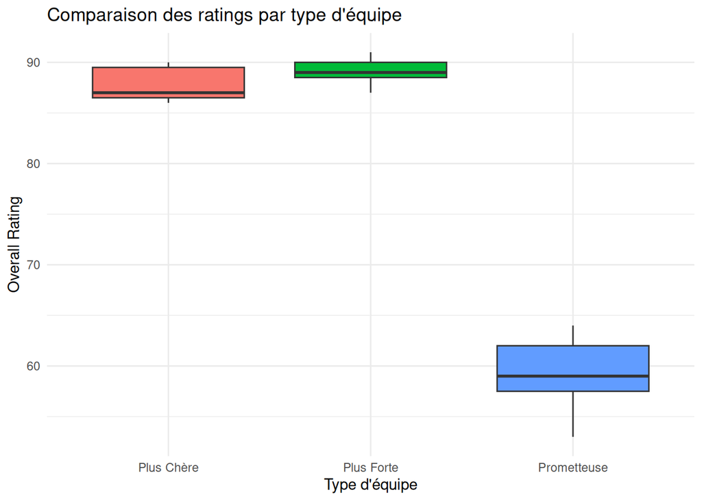

```r
ggplot(equipes_comparison, aes(x = Type, y = overall_rating, fill = Type)) +
  geom_boxplot() +
  labs(title = "Comparaison des ratings par type d'équipe",
       x = "Type d'équipe", y = "Overall Rating") +
  theme_minimal() +
  theme(legend.position = "none")
```

Comme observer précedement, nous avons des valeurs de médiane de `Overall Rating` plus élevés pour l’équipe la plus chère et l’équipe la plus forte, avec une médiane un peu plus au dessus pour l’équipe la plus forte ce qui est logique et vient même de l’essence de l’équipe la plus forte. Cette légère variation vient encore confirmer notre conclusion sur la correlation entre la valeur marchand et le overall rating. Et comme attendu nous avons une assez faible dispertion de la valeur du overall rating pour l’équipe la plus forte. Quant à l’équipe la plus prometteuse, nous avons une médiane rélativement basse par rapport aux autres équipes, ce qui est tout à fait logique et s’explique par le jeune âge des joueurs de cette équipe.